# Untitled

Jose Pablo Gómez Mata

7/6/2022

### Paquetes

```r
library(keras) # for deep learning
library(tidyverse) # general utility functions
library(caret) # machine learning utility functions
```

```r
library(tibble)
library(readr)
library(ggplot2)
library(tensorflow)
library(neuralnet)
library(grid)
library(lubridate)
```

## Datos

Los datos disponibles son aquellos que a su vez fueron utilizados para el proyecto anterior publicado en el 2022 donde se hacen las predicciones con modelos RF y GAMLSS. Para el modelo de redes neuronales se decidió utilizar las variables climáticas del DLNM, el RR del mes anterior y variables temporales de año y mes.

```r
load("base_cantones.RData")

basecanton = basecanton  %>%

  dplyr::select(Canton, Year,Month,Nino34SSTA1, Nino34SSTA2, Nino34SSTA3, Nino34SSTA4, Nino34SSTA5, Nino34SSTA6, TNA1,TNA2, NDVI1, NDVI2, LSD1, LSD2, Precip_t1, Precip_t2, Precip_t3, Precip_t4, Precip_t5, Precip_t6, RRl1, RR) %>%

  arrange(Canton,Year,Month) %>% ungroup() %>% mutate(Month=as.numeric(Month))

#Funciones
normalize <- function(x) {
  return ((x - min(x)) / (max(x) - min(x)))
}
denorm <- function(x,base) {
  return (x*(max(base$RR) - min(base$RR))+min(base$RR))
}

 metricas <- function(tabla){
    NRMSE <- mean((tabla$y_pred-tabla$RR)^2)/mean(tabla$RR)
    NIS_95 <- mean((tabla$LS-tabla$LI)+
                   (2/0.05)*(tabla$LI-tabla$RR)*(tabla$RR<tabla$LI)+
                   (2/0.05)*(tabla$RR-tabla$LS)*(tabla$RR>tabla$LS))/mean(tabla$RR)
    return(data.frame(NRMSE,NIS_95))
  }

predice = function(x) {
  y_values = (model %>% predict(x))
  result = (y_values*(max(base$RR) - min(base$RR))+min(base$RR))
  return (as.numeric(result))
}




basecanton2 = basecanton %>% group_by(basecanton$Canton) %>%
  mutate_if(is.numeric, normalize)
```

```
## `mutate_if()` ignored the following grouping variables:
## • Column `basecanton$Canton`
```

```r
basecanton2 = basecanton2[,-24]

#Train y test
data_train = as.data.frame(basecanton2) %>% filter(Year < 1)#PARA ENTRENAR HASTA 2018
data_test = as.data.frame(basecanton2) %>% filter(Year >= 1)
X_train = data_train[,-ncol(data_train)]
y_train = as.data.frame(data_train[,c("Canton","RR")])
X_test = as.data.frame(data_test[,-ncol(data_test)])
y_test = as.data.frame(data_test[,c("Canton","RR")])
Fecha = paste(basecanton$Year, basecanton$Month)
Fecha = Fecha[1:235]
Mes = basecanton$Month
Mes = Mes[1:235]
```

# Arquitectura del modelo

Aquí se plantea la arquitectura del modelo. Se comenzó con una arquitectura simple a la que se le fueron añadiendo capas y neuronas por capa hasta ir mejorando los resultados.

```r
model <- keras_model_sequential()
```

```
## Loaded Tensorflow version 2.8.0
```

```r
# our input layer
model %>%
  layer_simple_rnn(units = 100, input_shape = c(ncol(X_train)-1,1), activation='tanh',
                   kernel_initializer= initializer_constant(0.5),
                   bias_initializer=initializer_zeros()) %>%
  layer_dense(units = 50, activation = "relu")%>%
  layer_dense(units = 50, activation = "relu")%>%
  layer_dense(units = 50, activation = "relu")%>%
  layer_dropout(rate = 0.1)%>%
  layer_dense(units = 25, activation = "relu")%>%
  layer_dense(units = 25, activation = "relu")%>%
  layer_dense(units = 25, activation = "relu")%>%
  layer_dropout(rate = 0.1)%>%
  layer_dense(units = 12, activation = "relu")%>%
  layer_dense(units = 12, activation = "relu")%>%
  layer_dropout(rate = 0.1)%>%
  layer_dense(units = 6, activation = "relu")%>%
  layer_dense(units = 6, activation = "relu")%>%

  layer_dense(units = 1, activation = "sigmoid")
```

# Entrenamiento y predicciones

1. Se crean listas para almacenar los resulados de los modelos de cada cantón tanto de gráficos (denominadas con “p”), como riesgo relativo (df).
2. Se tiene una variable con los cantones a analizar llamada “Cantones”.
3. Se tiene una evaluación para los valores ajustados junto con los predichos llamada #Eval.tot” para almacener resultados de NRMSE y NIS. A su vez se almacenan los valores de NRMSE y NIS de los últmos tres meses en “Eval.pd”.
4. Se crea un ciclo for para cada cantón donde se obtienen los valores de train y test particulares para ese cantón, posterior a esto se compila y entrena el modelo con estos datos y se predice los valores para los tres últimos meses. También se usa “predict” para obtener valores ajustados del modelo a lo largo de los años de estudio.
5. Posterior a esto se crea un ciclo de bootstrap para la creación de intervalos de confianza tomando los valores de cada mes del año por separado para generar el intervalo.
6. Por último se aplican las funciones de métricas y se crean gráficos para observar la información

```r
# Se obtienen los nombres de todos los cantones
Cantones = unique(basecanton$Canton)


#Variables de almacenamiento de métricas, gráficos y resultados numéricos
Eval.pd = matrix(ncol = 2, nrow = length(Cantones))
Eval.tot = matrix(ncol = 2, nrow = length(Cantones))
p1 = list()
p2 = list()
p3 = list()
df1 = list()
df2 = list()
df3 = list()


for (i in 1:length(Cantones)) {

  #Se obtienen los valores de RR reales para el cantón i
  base = as.data.frame(basecanton %>% filter(Canton == Cantones[i]) %>% dplyr::select(RR))

  #Se obtienen train y test para el cantón i y se combierten en matriz
  X_trainc = X_train %>% filter(Canton == Cantones[i])
  X_trainc = as.matrix(X_trainc[,-1])
  y_trainc = y_train %>% filter(Canton == Cantones[i])
  y_trainc = as.matrix(y_trainc[,-1])

  X_testc = X_test %>% filter(Canton == Cantones[i])
  X_testc = as.matrix(X_testc[,-1])
  y_testc = y_test %>% filter(Canton == Cantones[i])
  y_testc = as.matrix(y_testc[,-1])
  y_testc = denorm(y_testc, base)


  #Se compila el modelo midiendo el error con el error cuadrático medio, optimizador adam con un rate de aprendizaje de 0.0007.


  model %>% compile(loss = "mse",
                    optimizer = optimizer_adam(lr = 0.0007),
                    metric = "mean_absolute_error")

  # Se entrena el modelo
  trained_model <- model %>% fit(
    x = X_trainc,
    y = y_trainc,
    batch_size = 18,
    epochs = 65,
    validation_split = 0.1,
    shuffle = F)


  #### VALORES PREDICHOS ####
  # Para predecir los últimos 3 meses estos se predicen y se guarda el valor de RR obtenido en la variabale RRl del mes siguiente para que lo utilice para su predicción. Esto se almacena en la variable "pred".
  pred = NULL
  # predicciones a 3 meses
  for (k in 1:2) {
    pred[k] = predice(X_testc)[k]
    X_testc[k+1,21] = pred[k]
  }
  pred[3] = predice(X_testc)[3]


  # Se crea una base para las predicciones, "df1", que tiene los valores predichos, los valores reales, fecha y mes.
  df1[[i]] = as.data.frame(cbind(pred, y_testc, Fecha[233:235],Mes[233:235]))
  colnames(df1[[i]]) = c("y_pred", "RR", "Fecha","Mes")
  df1[[i]]$RR = as.numeric(df1[[i]]$RR)
  df1[[i]]$y_pred = as.numeric(df1[[i]]$y_pred)



  #### VALORES APROXIMADOS ####
  ## Se generan los valores ajustados por medio de predict y se guardan en la variable "df2".

  df2[[i]] = as.data.frame(cbind(predice(X_trainc), base$RR[1:232], Fecha[1:232], Mes[1:232]))
  colnames(df2[[i]]) = c("y_pred", "RR", "Fecha","Mes")
  df2[[i]]$RR = as.numeric(df2[[i]]$RR)
  df2[[i]]$y_pred = as.numeric(df2[[i]]$y_pred)
  df2[[i]] = rbind(df2[[i]], df1[[i]])


  #### BOOTSTRAP ####
  # Aquí se haceno las predicciones del 2000 hasta el 2020 con intervalos de bootstrap

LI = matrix(ncol = 1, nrow = 235) #Almacena Límite inferior
LS = matrix(ncol = 1, nrow = 235) #Almacena Límite Superior

  for (j in 1:12) {

    indx = which(df2[[i]]$Mes== j) # índice de la posición de del mes j en la base de datos

    x <- df2[[i]][Mes==j,1] # tomo todos los meses j con las predicciones para cada mes (es decir que tomo el mes j para los años que hayan reportados)
    x <- as.numeric(x)
    n <- length(x) # voy a hacer un remuestreo para la cantidad de observaciones que tenga de ese mes j
    Tn <- mean(x) # saco la media para estos datos

    B <- 500
    Tboot_b <- NULL
    for(b in 1:B) {
      xb <- sample(x, size = n, replace = TRUE)
      Tboot_b[b] <- mean(xb)
    }
    # calculo de estadisticos de bootstrap
    Tboot <- mean(Tboot_b)
    Vboot <- var(Tboot_b)
    sdboot <- sqrt(Vboot)

    # ahora el IC de bootstrap estudentizado
    B <- 500
    Tboot_b <- NULL
    Tboot_bm <- NULL
    sdboot_b <- NULL

    for (b in 1:B) {
      xb <- sample(x, size = n, replace = TRUE)
      Tboot_b[b] <- mean(xb) # la media
      for (m in 1:B) {
        xbm <- sample(xb, size = n, replace = TRUE)
        Tboot_bm[m] <- mean(xbm)
      }
      sdboot_b[b] <- sd(Tboot_bm)
    }

    z_star <- (Tboot_b - Tn) / sdboot_b

    # se crean los limites inferiores y superiores
    LI[indx,] = as.numeric(df2[[i]][Mes==j,1]) - quantile(z_star, 1 - 0.05 / 2) * sdboot
    LS[indx,] = as.numeric(df2[[i]][Mes==j,1]) - quantile(z_star, 0.05 / 2) * sdboot
  }



  #Añadir límites a la base df2 y df1

  df2[[i]] = cbind(df2[[i]], LI, LS)
  df1[[i]] = cbind(df1[[i]], LI[233:235], LS[233:235])
  colnames(df1[[i]]) = c("y_pred","RR","Fecha","Mes","LI","LS")

  df3[[i]] = df2[[i]][185:235,]


  ### Gráficos ###


  everyother1 <- function(x) x[(seq_along(Fecha) + 5)%%12 == 6]   #Función para estética del gráfico, acomoda las Fechas para que no se muestren todas, sino cada 6 meses.

  p1[[i]] = ggplot(df1[[i]], aes(x = Fecha, y = RR, group = 1)) + geom_line(colour = "blue") +
    geom_line( aes(x = Fecha, y = y_pred, colour = "red"))+
    theme(panel.grid.major = element_blank(), panel.grid.minor = element_blank(),
          panel.background = element_blank(), axis.text.x = element_text(angle = 45), legend.position = "none" )+
    labs (x = "Fecha", y = "Riesgo Relativo") + geom_ribbon(aes(ymin= LI,ymax= LS), alpha=0.2, fill = "red") +
    ggtitle(paste("Predicciones 2021 del cantón", Cantones[i], sep = " "))


  p2[[i]] = ggplot(df2[[i]], aes(x = Fecha, y = RR, group = 1)) + geom_line(colour = "blue") +
    geom_line(aes(x = Fecha, y = y_pred, colour = "red"))+
    theme(panel.grid.major = element_blank(), panel.grid.minor = element_blank(),
          panel.background = element_blank(), axis.text.x = element_text(angle = 45), legend.position = "none" )+
    scale_x_discrete(breaks = everyother1) + labs (x = "Fecha", y = "Riesgo Relativo") +
    geom_ribbon(data = df1[[i]], aes(ymin = LI,ymax= LS), alpha=0.5, fill = "red") +
    # scale_y_continuous(breaks = seq(min(RR), max(RR), 10)) +
    ggtitle(paste(Cantones[i]))

  p3[[i]] = ggplot(df3[[i]], aes(x = Fecha, y = RR, group = 1)) + geom_line(colour = "blue") +
    geom_line(aes(x = Fecha, y = y_pred, colour = "red"))+
    theme(panel.grid.major = element_blank(), panel.grid.minor = element_blank(),
          panel.background = element_blank(), axis.text.x = element_text(angle = 45), legend.position = "none" )+
    scale_x_discrete(breaks = everyother1) + labs (x = "Fecha", y = "Riesgo Relativo") +
    geom_ribbon(data = df1[[i]], aes(ymin = LI,ymax= LS), alpha=0.5, fill = "red") +
    # scale_y_continuous(breaks = seq(min(RR), max(RR), 10)) +
    ggtitle(paste("Últimos 4 años: ", Cantones[i]))





  Eval.pd[i,] = as.numeric(metricas(df1[[i]]))
  Eval.tot[i,] = as.numeric(metricas(df2[[i]]))


  k_clear_session()
}
```

[output not shown]

[output cut: 40 more lines]

[output not shown]

## Resultados de métricas

```r
library(kableExtra)
Metricas = cbind (round(Eval.pd,3), round(Eval.tot,3))
colnames(Metricas) = c("NMRSE_2021", "NIS_2021", "NMRSE_Total", "NIS_total")
rownames(Metricas) = Cantones
met <- as.data.frame(Metricas)


met$NMRESE_2021 =cell_spec(met$NMRSE_2021, color = ifelse(met$NMRSE_2021>100,"red",ifelse(met$NMRSE_2021>50,"orange","blue")))


kbl(met[,c(5,2,3,4)], escape = F) %>% kable_paper("striped", full_width = F)
```

|  | NMRESE_2021 | NIS_2021 | NMRSE_Total | NIS_total |
| --- | --- | --- | --- | --- |
| Alajuela | 2.03 | 36.890 | 0.353 | 7.955 |
| Alajuelita | 0.498 | 22.584 | 0.271 | 21.125 |
| Atenas | 161.343 | 590.701 | 2.155 | 14.477 |
| Cañas | 531.504 | 833.976 | 2.809 | 7.212 |
| Carrillo | 191.699 | 353.357 | 2.790 | 11.915 |
| Corredores | 36.072 | 136.215 | 1.761 | 8.603 |
| Desamparados | 0.004 | 1.485 | 0.082 | 8.323 |
| Esparza | 215.4 | 398.109 | 3.514 | 17.263 |
| Garabito | 1404.085 | 2017.810 | 2.652 | 6.090 |
| Golfito | 105.058 | 386.810 | 1.639 | 11.440 |
| Guacimo | 7.941 | 34.194 | 0.686 | 4.437 |
| La Cruz | 915.552 | 1924.081 | 3.790 | 17.760 |
| Liberia | 365.453 | 1219.902 | 1.249 | 7.573 |
| Limon | 4.449 | 24.318 | 0.674 | 5.418 |
| Matina | 125.366 | 336.556 | 1.875 | 8.074 |
| Montes de Oro | 129.216 | 393.021 | 2.177 | 9.443 |
| Nicoya | 186.228 | 880.435 | 0.875 | 7.249 |
| Orotina | 245.842 | 246.355 | 3.542 | 6.946 |
| Osa | 10.834 | 41.245 | 2.158 | 14.534 |
| Parrita | 9889.252 | 3361.318 | 24.661 | 20.374 |
| Perez Zeledón | 0.756 | 16.986 | 0.478 | 8.627 |
| Pococí | 47.328 | 160.663 | 0.628 | 3.194 |
| Puntarenas | 60.984 | 261.296 | 0.680 | 5.466 |
| Quepos | 5951.033 | 4275.094 | 10.672 | 18.845 |
| San Jose | 0.266 | 25.338 | 0.042 | 3.856 |
| Santa Ana | 0.648 | 39.183 | 0.254 | 10.282 |
| SantaCruz | 992.08 | 1338.016 | 3.583 | 10.011 |
| Sarapiquí | 157.39 | 259.524 | 2.964 | 9.484 |
| Siquirres | 25.104 | 95.903 | 0.716 | 3.685 |
| Talamanca | 1.218 | 5.005 | 2.477 | 16.577 |
| Turrialba | 1.851 | 33.356 | 1.651 | 17.078 |
| Upala | Inf | Inf | 0.870 | 19.150 |

## Gráficos

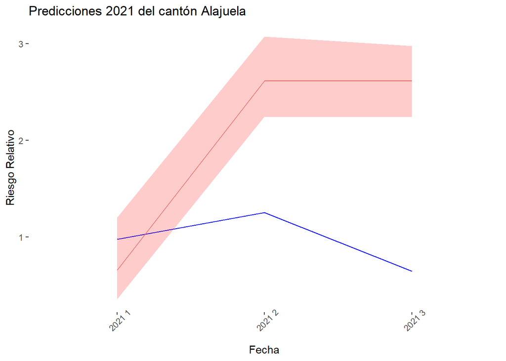

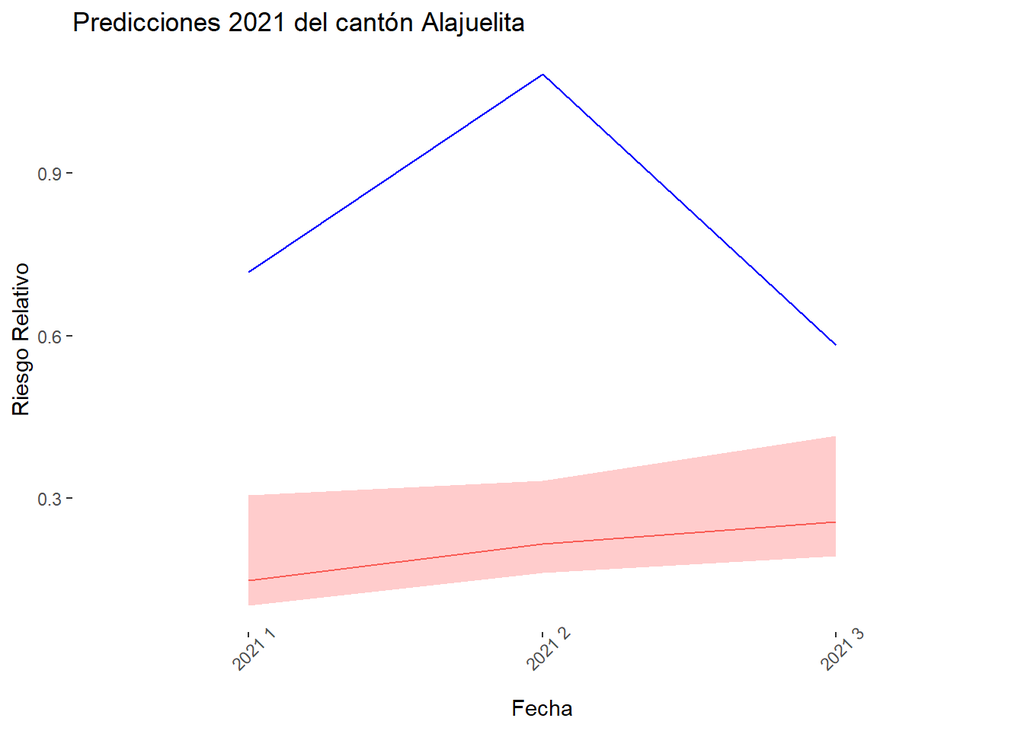

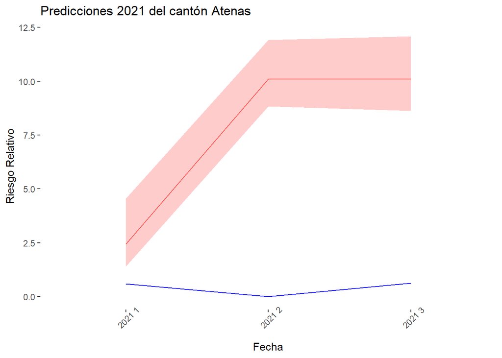

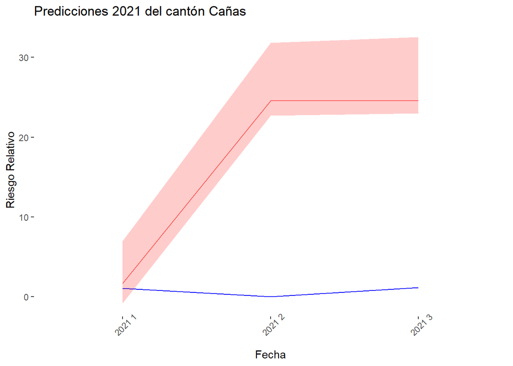

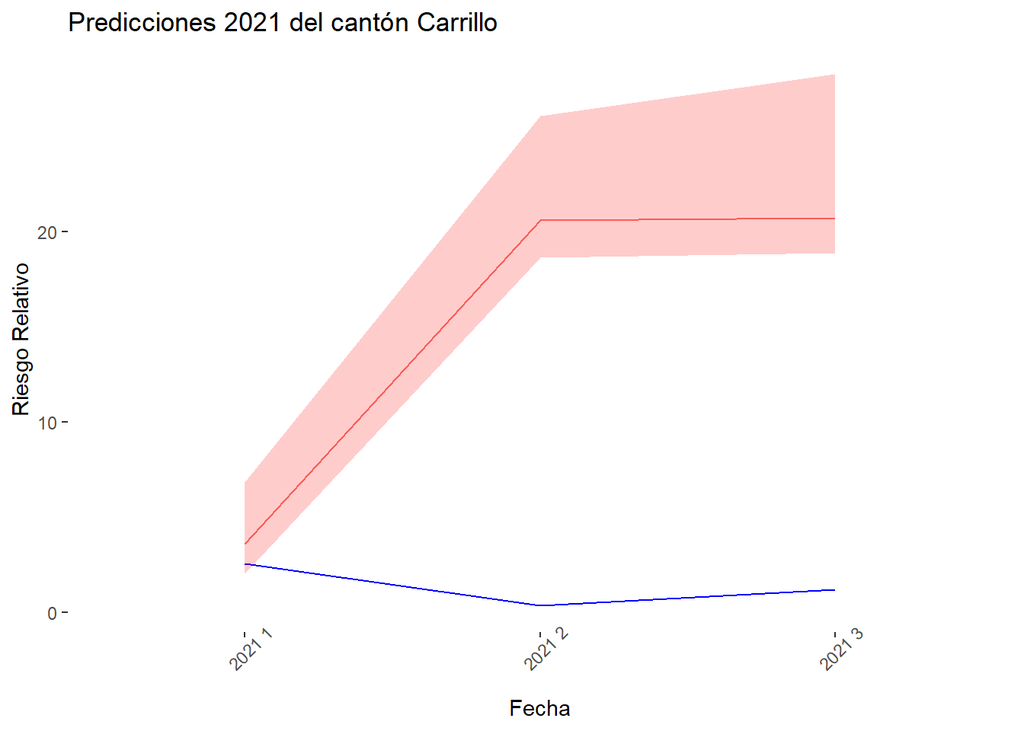

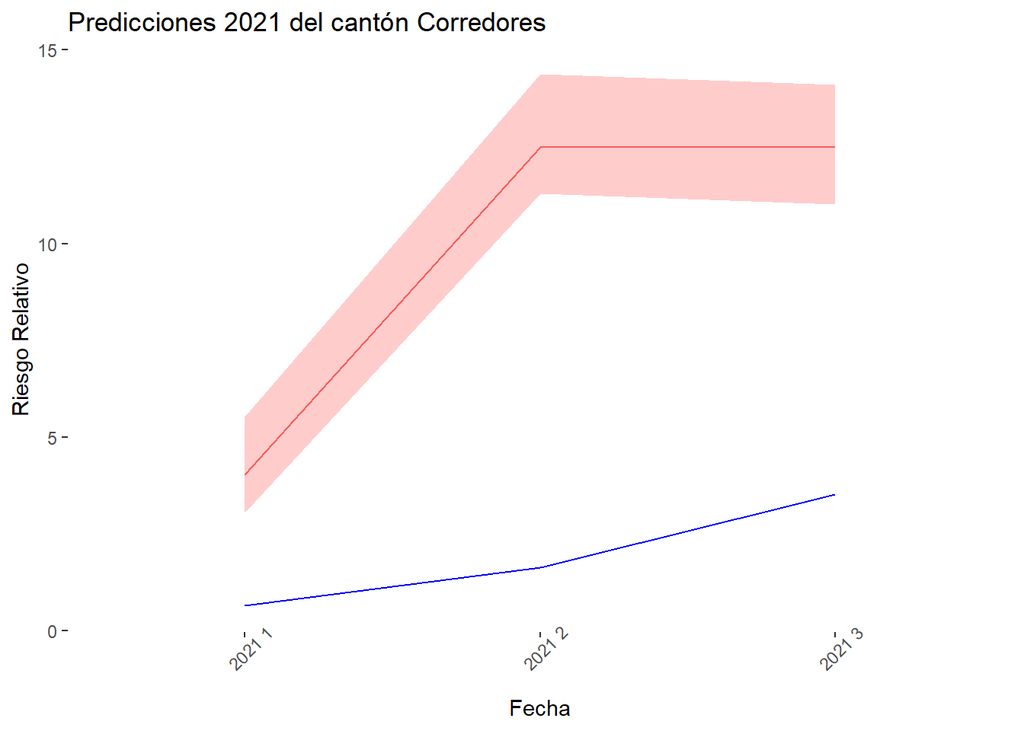

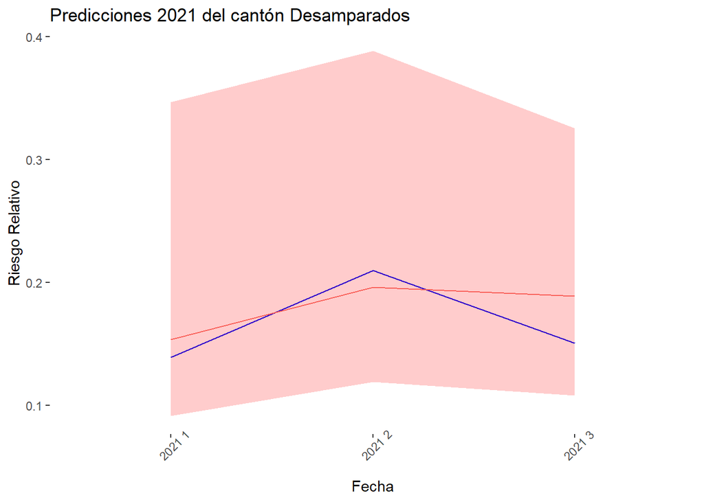

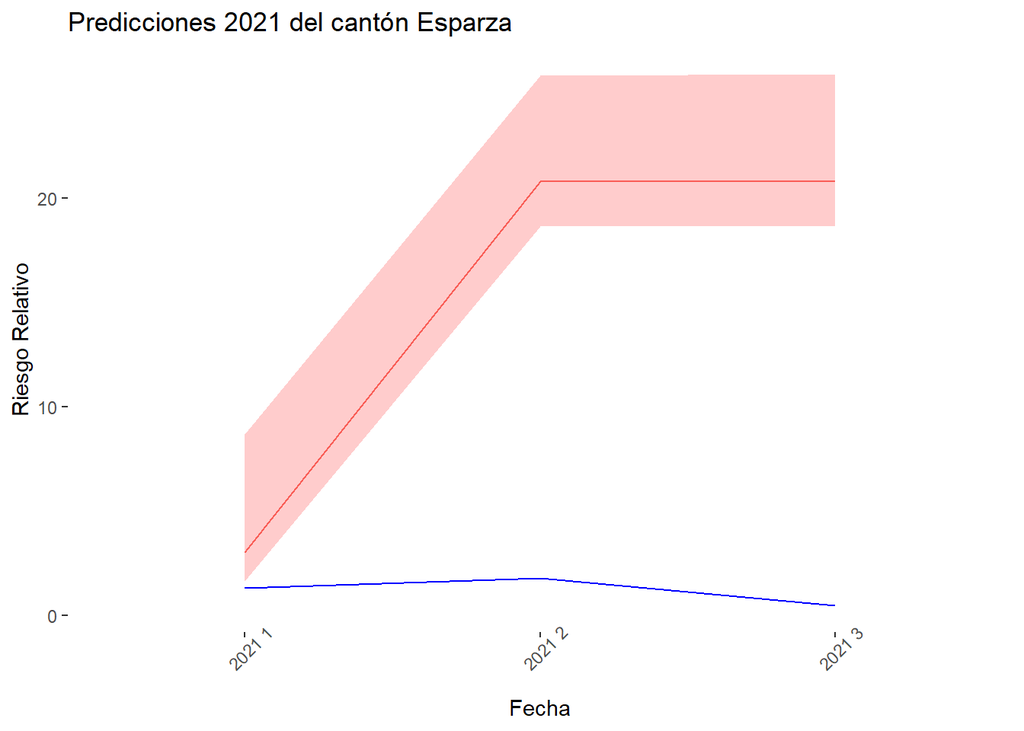

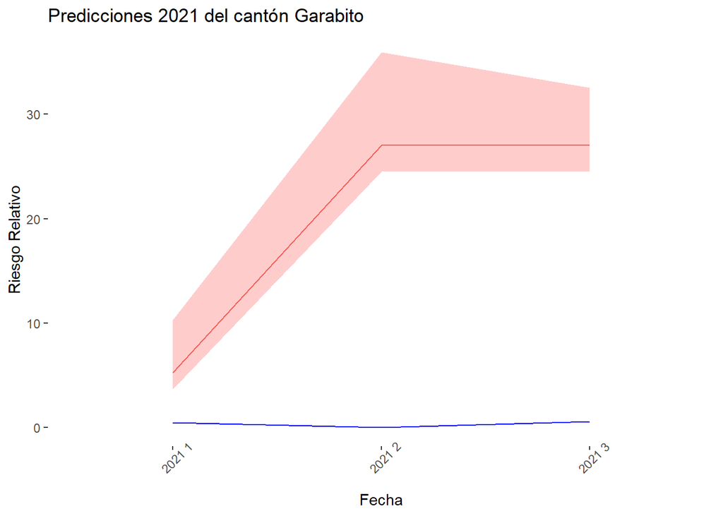

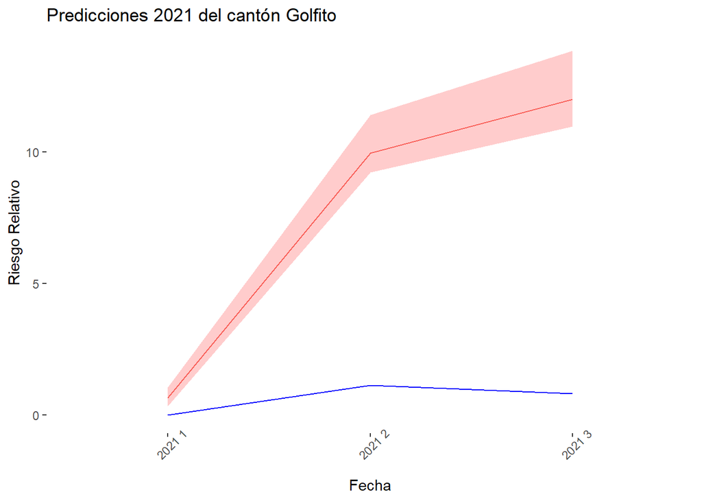

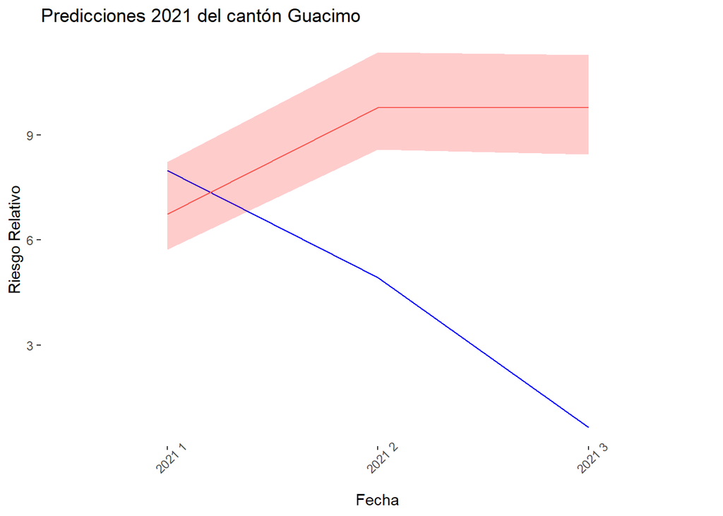

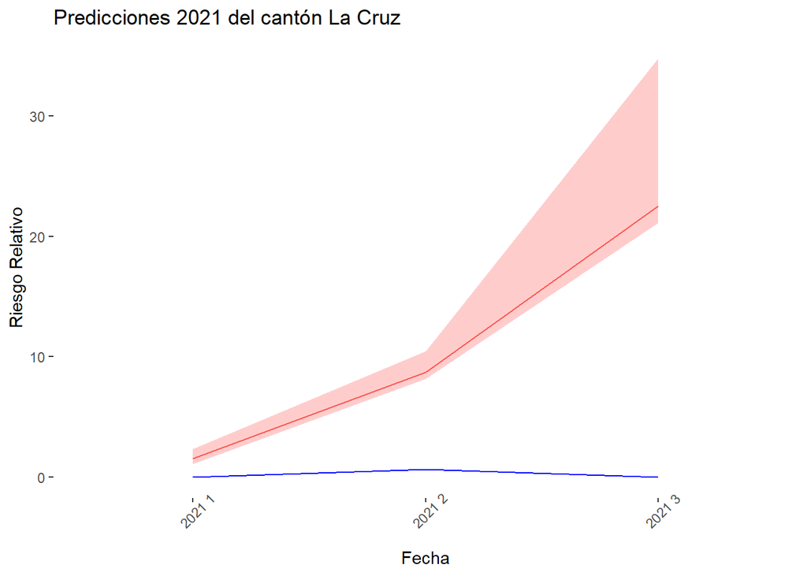

[20 more figures not shown]

```r
p1
```

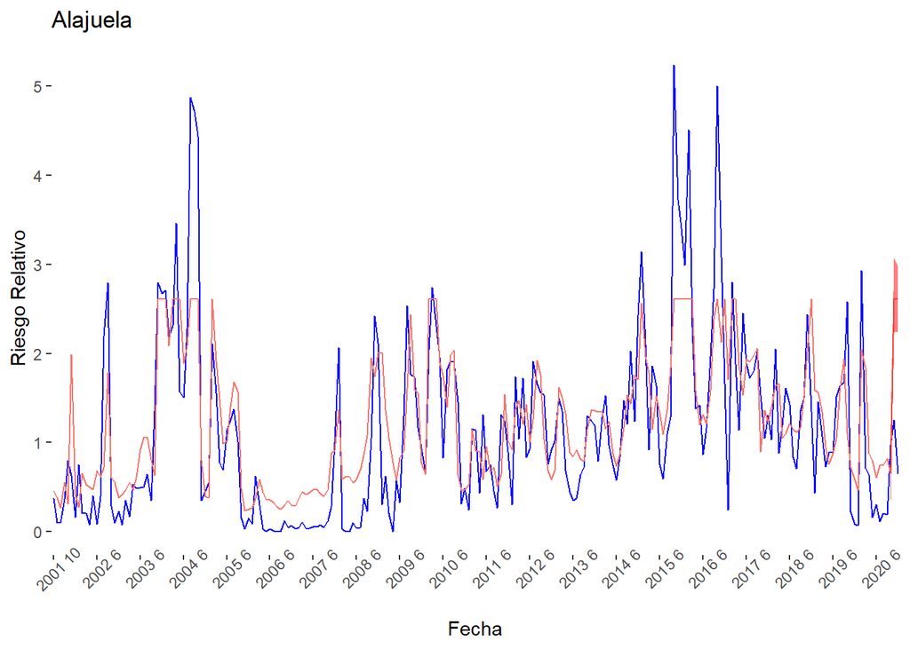

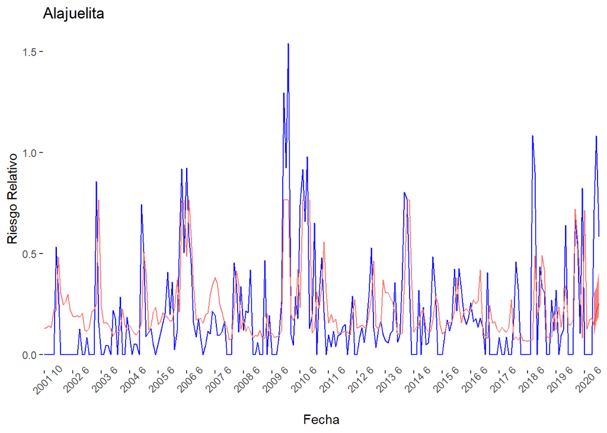

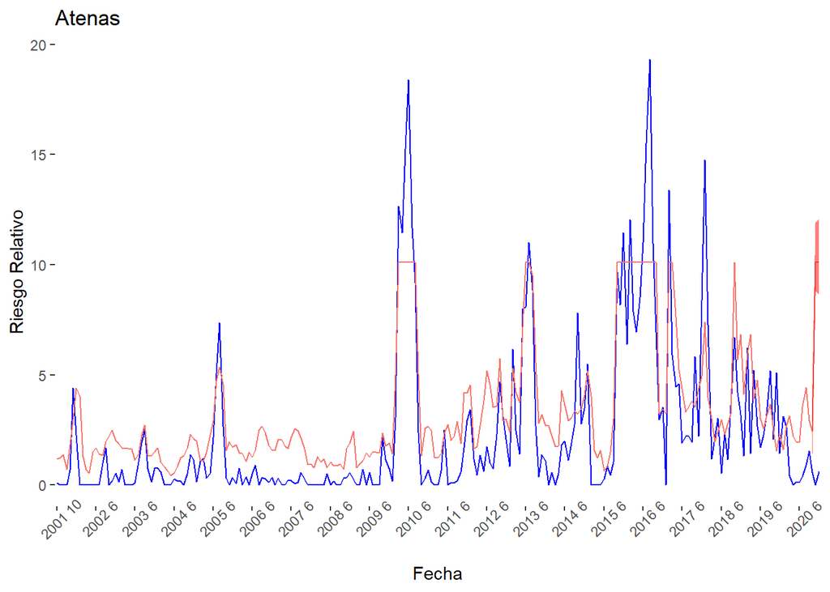

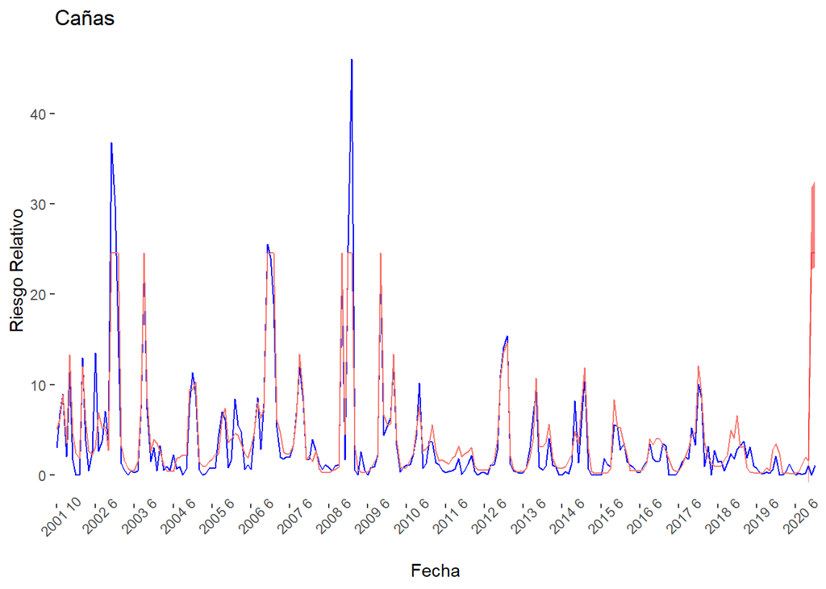

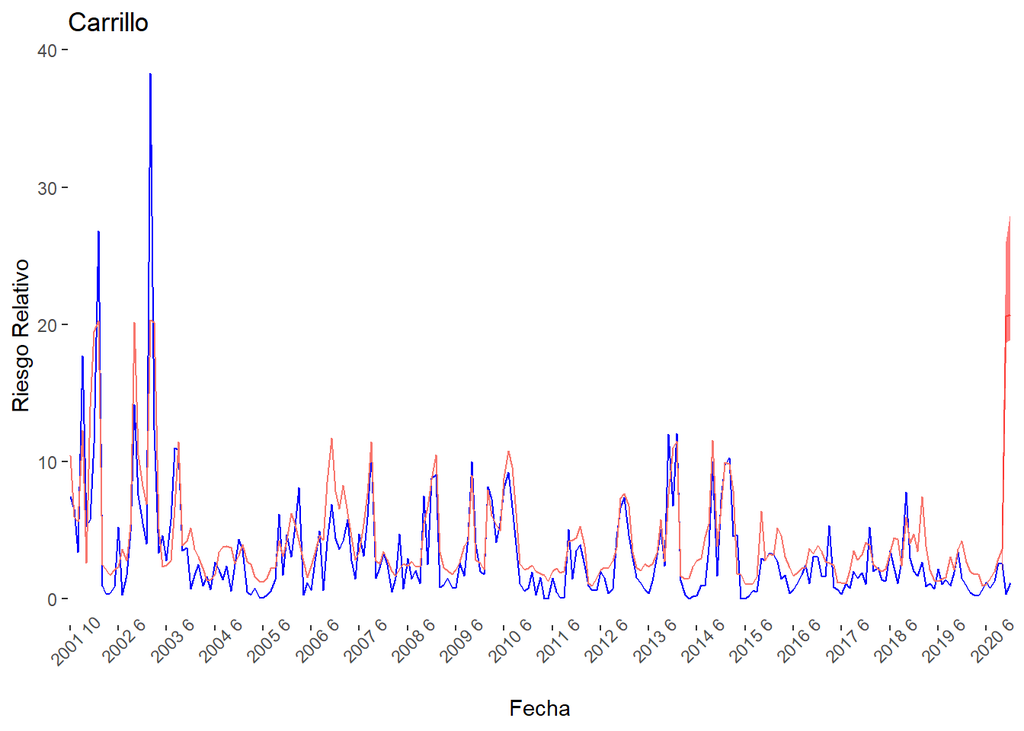

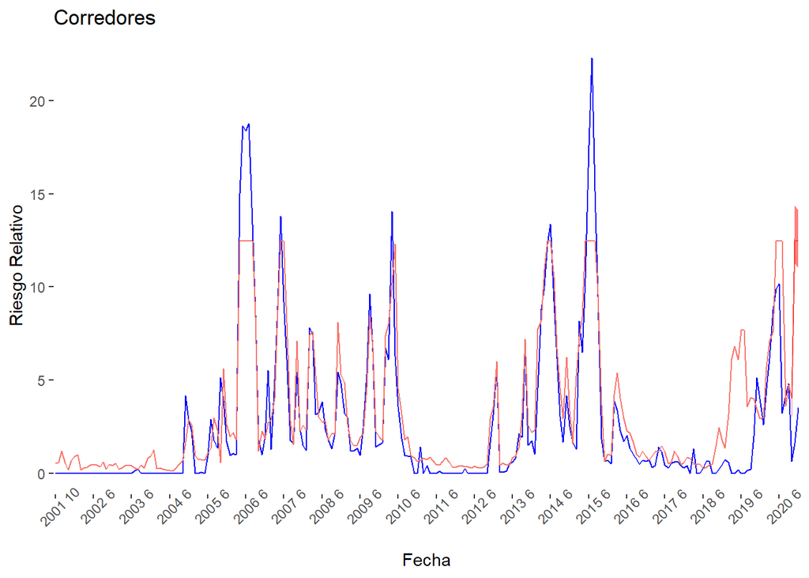

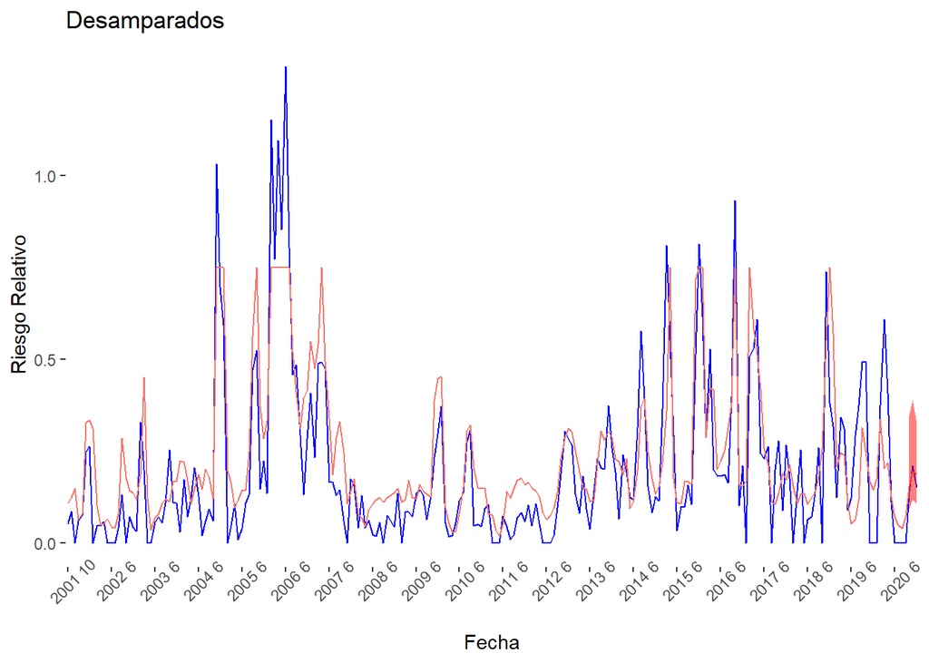

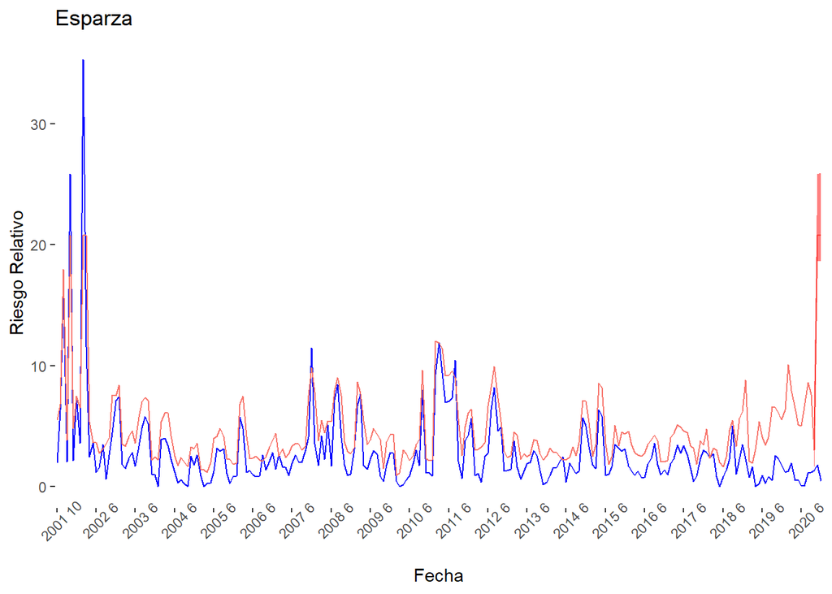

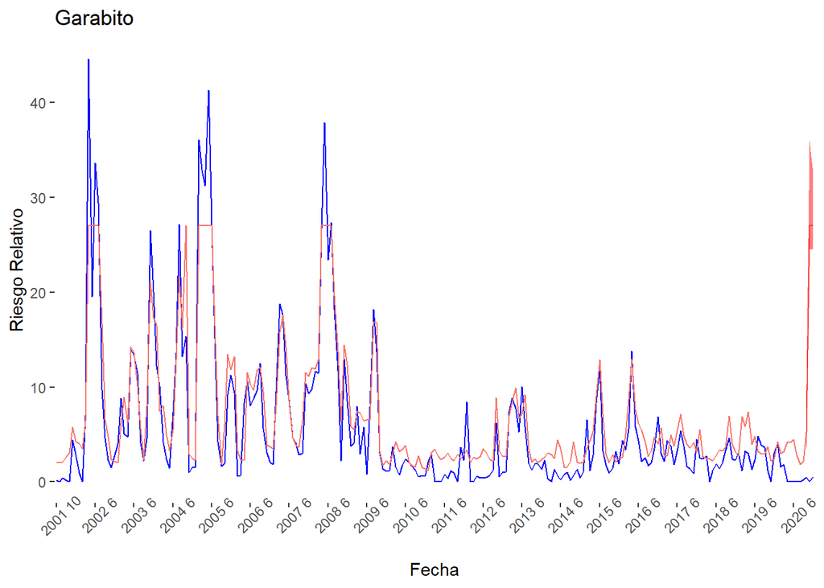

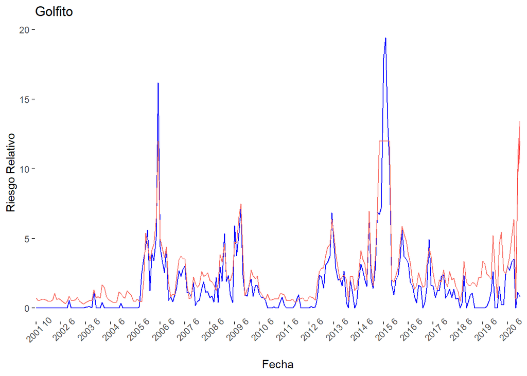

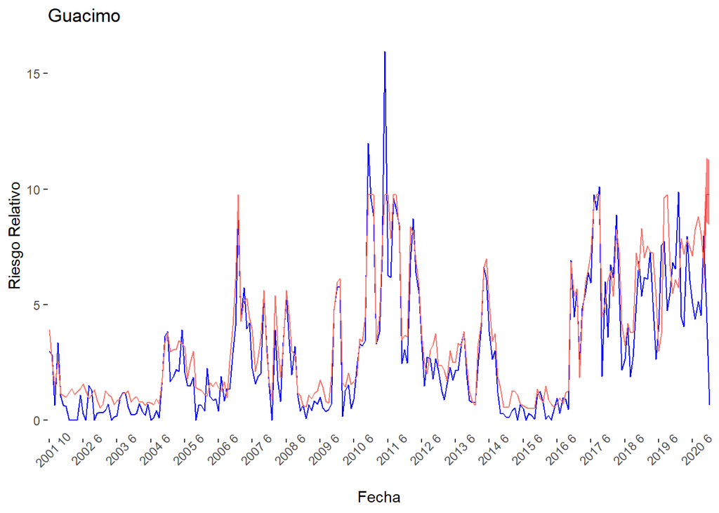

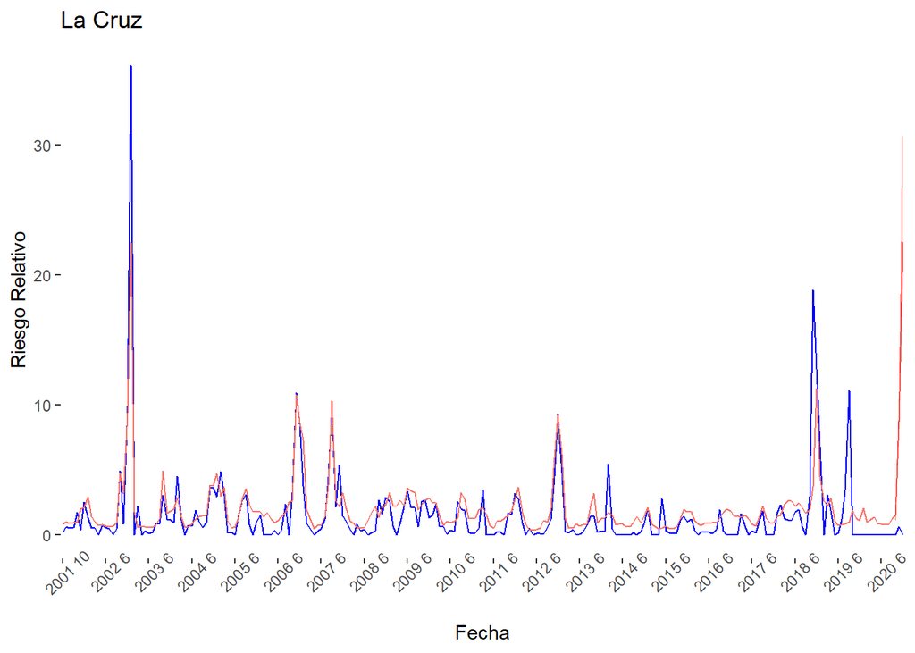

[20 more figures not shown]

```r
p2
```